# P1P2_Seb

2025-10-29

```r
colnames(bac) <- colnames(bac) %>%
  str_to_lower() %>%
  str_replace_all(" \\(.*\\)", "") %>%
  str_replace_all("[^a-z0-9_]", "")

bac <- bac %>%
  mutate(beta60 = abs(beta60))
```

```r
bac %>% summarise(
  n = n(),
  mean_beta = mean(beta60, na.rm = TRUE),
  sd_beta = sd(beta60, na.rm = TRUE),
  min_beta = min(beta60, na.rm = TRUE),
  max_beta = max(beta60, na.rm = TRUE)
)
```

```
## # A tibble: 1 × 5
##       n mean_beta sd_beta min_beta max_beta
##   <int>     <dbl>   <dbl>    <dbl>    <dbl>
## 1   100     0.184  0.0330    0.124    0.275
```

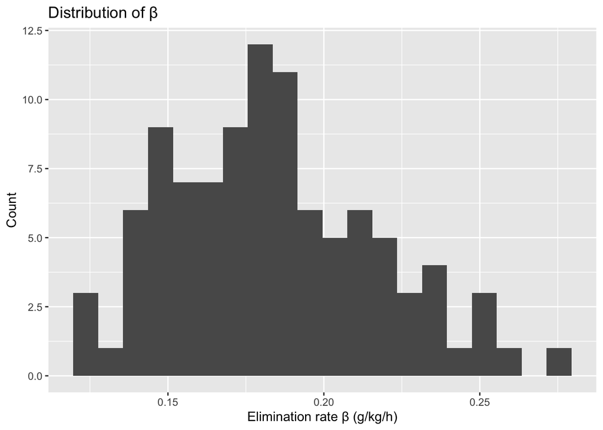

```r
# Visuals
ggplot(bac, aes(beta60)) +
  geom_histogram(bins = 20) +
  labs(x = "Elimination rate β (g/kg/h)", y = "Count",
       title = "Distribution of β")
```

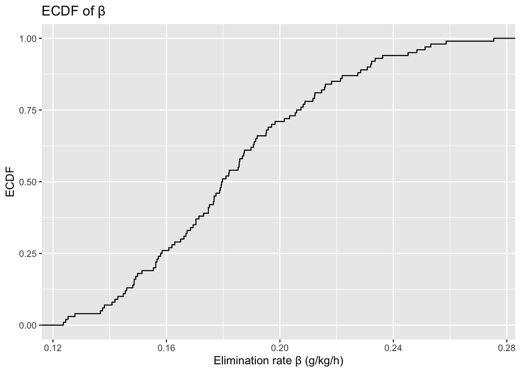

```r
ggplot(bac, aes(beta60)) +
  stat_ecdf() +
  labs(x = "Elimination rate β (g/kg/h)", y = "ECDF",
       title = "ECDF of β")
```

```r
quantile(bac$beta60, c(0.025, 0.975))
```

```
##      2.5%     97.5%
## 0.1264760 0.2522341
```

```r
summary(bac$beta60)
```

```
##    Min. 1st Qu.  Median    Mean 3rd Qu.    Max.
##  0.1237  0.1583  0.1796  0.1840  0.2063  0.2754
```

```r
sd(bac$beta60)
```

```
## [1] 0.03297403
```

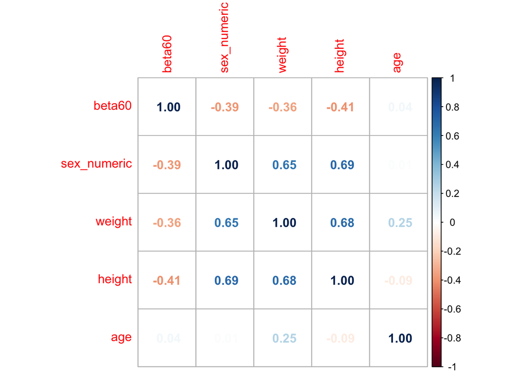

```r
library(corrplot)
vars <- c("beta60", "sex_numeric", "weight", "height", "age")
bac$sex_numeric <- ifelse(bac$sex == "male", 1, 0)
cor_matrix <- cor(bac[, vars], use="complete.obs")
corrplot(cor_matrix, method="number")
```

sex is a potential confounding factor.

```r
m1 <- lm(beta60 ~ sex, data=bac)
summary(m1)
```

```
##
## Call:
## lm(formula = beta60 ~ sex, data = bac)
##
## Residuals:
##       Min        1Q    Median        3Q       Max
## -0.059436 -0.024300 -0.003378  0.018752  0.075174
##
## Coefficients:
##              Estimate Std. Error t value Pr(>|t|)
## (Intercept)  0.200242   0.004954  40.422  < 2e-16 ***
## sexmale     -0.026267   0.006291  -4.175 6.46e-05 ***
## ---
## Signif. codes:  0 '***' 0.001 '**' 0.01 '*' 0.05 '.' 0.1 ' ' 1
##
## Residual standard error: 0.03054 on 98 degrees of freedom
## Multiple R-squared:  0.151,  Adjusted R-squared:  0.1423
## F-statistic: 17.43 on 1 and 98 DF,  p-value: 6.46e-05
```

```r
m2 <- lm(beta60 ~ weight + height, data=bac)
summary(m2)
```

```
##
## Call:
## lm(formula = beta60 ~ weight + height, data = bac)
##
## Residuals:
##       Min        1Q    Median        3Q       Max
## -0.065019 -0.020935 -0.005458  0.017894  0.069018
##
## Coefficients:
##               Estimate Std. Error t value Pr(>|t|)
## (Intercept)  0.4088605  0.0652516   6.266 1.02e-08 ***
## weight      -0.0003993  0.0003525  -1.133   0.2601
## height      -0.0011143  0.0004513  -2.469   0.0153 *
## ---
## Signif. codes:  0 '***' 0.001 '**' 0.01 '*' 0.05 '.' 0.1 ' ' 1
##
## Residual standard error: 0.03019 on 97 degrees of freedom
## Multiple R-squared:  0.1787, Adjusted R-squared:  0.1617
## F-statistic: 10.55 on 2 and 97 DF,  p-value: 7.146e-05
```

```r
m3 <- lm(beta60 ~ sex + weight + height, data=bac)
summary(m3)
```

```
##
## Call:
## lm(formula = beta60 ~ sex + weight + height, data = bac)
##
## Residuals:
##       Min        1Q    Median        3Q       Max
## -0.059692 -0.020626 -0.003934  0.018959  0.070271
##
## Coefficients:
##               Estimate Std. Error t value Pr(>|t|)
## (Intercept)  0.3538963  0.0777973   4.549 1.58e-05 ***
## sexmale     -0.0117009  0.0090901  -1.287    0.201
## weight      -0.0002411  0.0003722  -0.648    0.519
## height      -0.0008252  0.0005028  -1.641    0.104
## ---
## Signif. codes:  0 '***' 0.001 '**' 0.01 '*' 0.05 '.' 0.1 ' ' 1
##
## Residual standard error: 0.03009 on 96 degrees of freedom
## Multiple R-squared:  0.1926, Adjusted R-squared:  0.1674
## F-statistic: 7.634 on 3 and 96 DF,  p-value: 0.0001249
```

```r
m4 <- lm(beta60 ~ sex + weight + height + age, data=bac)
summary(m4)
```

```
##
## Call:
## lm(formula = beta60 ~ sex + weight + height + age, data = bac)
##
## Residuals:
##       Min        1Q    Median        3Q       Max
## -0.057851 -0.020688 -0.004088  0.019197  0.072505
##
## Coefficients:
##               Estimate Std. Error t value Pr(>|t|)
## (Intercept)  0.3390803  0.0827796   4.096 8.83e-05 ***
## sexmale     -0.0114824  0.0091329  -1.257    0.212
## weight      -0.0003360  0.0004130  -0.814    0.418
## height      -0.0007322  0.0005333  -1.373    0.173
## age          0.0001853  0.0003436   0.539    0.591
## ---
## Signif. codes:  0 '***' 0.001 '**' 0.01 '*' 0.05 '.' 0.1 ' ' 1
##
## Residual standard error: 0.0302 on 95 degrees of freedom
## Multiple R-squared:  0.1951, Adjusted R-squared:  0.1612
## F-statistic: 5.756 on 4 and 95 DF,  p-value: 0.0003427
```

```r
bac$BMI <- bac$weight / (bac$height/100)^2
m_bmi <- lm(beta60 ~ sex + BMI, data=bac)
summary(m_bmi)
```

```
##
## Call:
## lm(formula = beta60 ~ sex + BMI, data = bac)
##
## Residuals:
##       Min        1Q    Median        3Q       Max
## -0.059935 -0.023994 -0.003284  0.018582  0.074181
##
## Coefficients:
##               Estimate Std. Error t value Pr(>|t|)
## (Intercept)  0.2080508  0.0252906   8.226 8.84e-13 ***
## sexmale     -0.0256093  0.0066562  -3.847 0.000214 ***
## BMI         -0.0003635  0.0011543  -0.315 0.753512
## ---
## Signif. codes:  0 '***' 0.001 '**' 0.01 '*' 0.05 '.' 0.1 ' ' 1
##
## Residual standard error: 0.03068 on 97 degrees of freedom
## Multiple R-squared:  0.1519, Adjusted R-squared:  0.1344
## F-statistic: 8.685 on 2 and 97 DF,  p-value: 0.0003391
```

```r
m_weight <- lm(beta60 ~ sex + weight, data=bac)
summary(m_weight)
```

```
##
## Call:
## lm(formula = beta60 ~ sex + weight, data = bac)
##
## Residuals:
##       Min        1Q    Median        3Q       Max
## -0.058415 -0.021765 -0.002716  0.018759  0.076945
##
## Coefficients:
##               Estimate Std. Error t value Pr(>|t|)
## (Intercept)  0.2309818  0.0212383  10.876   <2e-16 ***
## sexmale     -0.0183659  0.0082032  -2.239   0.0274 *
## weight      -0.0005041  0.0003388  -1.488   0.1400
## ---
## Signif. codes:  0 '***' 0.001 '**' 0.01 '*' 0.05 '.' 0.1 ' ' 1
##
## Residual standard error: 0.03035 on 97 degrees of freedom
## Multiple R-squared:   0.17,  Adjusted R-squared:  0.1528
## F-statistic:  9.93 on 2 and 97 DF,  p-value: 0.0001193
```

```r
m_interact1 <- lm(beta60 ~ sex * weight, data=bac)
summary(m_interact1)
```

```
##
## Call:
## lm(formula = beta60 ~ sex * weight, data = bac)
##
## Residuals:
##       Min        1Q    Median        3Q       Max
## -0.058680 -0.021784 -0.003246  0.018389  0.077619
##
## Coefficients:
##                  Estimate Std. Error t value Pr(>|t|)
## (Intercept)     0.2229888  0.0375104   5.945 4.46e-08 ***
## sexmale        -0.0058225  0.0491062  -0.119    0.906
## weight         -0.0003731  0.0006098  -0.612    0.542
## sexmale:weight -0.0001905  0.0007350  -0.259    0.796
## ---
## Signif. codes:  0 '***' 0.001 '**' 0.01 '*' 0.05 '.' 0.1 ' ' 1
##
## Residual standard error: 0.0305 on 96 degrees of freedom
## Multiple R-squared:  0.1705, Adjusted R-squared:  0.1446
## F-statistic: 6.579 on 3 and 96 DF,  p-value: 0.0004314
```

```r
m_interact2 <- lm(beta60 ~ sex * height, data=bac)
summary(m_interact2)
```

```
##
## Call:
## lm(formula = beta60 ~ sex * height, data = bac)
##
## Residuals:
##       Min        1Q    Median        3Q       Max
## -0.054955 -0.022045 -0.003612  0.015951  0.069413
##
## Coefficients:
##                  Estimate Std. Error t value Pr(>|t|)
## (Intercept)     0.5812481  0.1368943   4.246 5.03e-05 ***
## sexmale        -0.3338515  0.1677848  -1.990  0.04946 *
## height         -0.0022626  0.0008124  -2.785  0.00645 **
## sexmale:height  0.0018580  0.0009723   1.911  0.05901 .
## ---
## Signif. codes:  0 '***' 0.001 '**' 0.01 '*' 0.05 '.' 0.1 ' ' 1
##
## Residual standard error: 0.0296 on 96 degrees of freedom
## Multiple R-squared:  0.2188, Adjusted R-squared:  0.1944
## F-statistic: 8.962 on 3 and 96 DF,  p-value: 2.719e-05
```

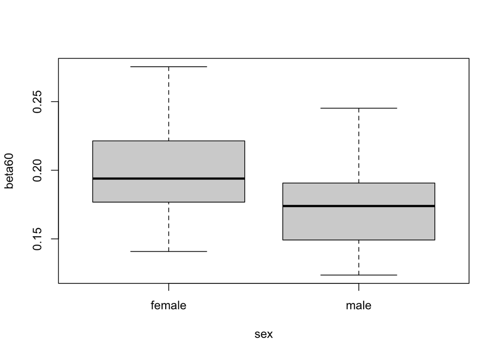

```r
# Boxplot
boxplot(beta60 ~ sex, data=bac)
```

```r
# T-test or Wilcoxon test
t.test(beta60 ~ sex, data=bac)
```

```
##
##  Welch Two Sample t-test
##
## data:  beta60 by sex
## t = 4.0793, df = 72.632, p-value = 0.0001144
## alternative hypothesis: true difference in means between group female and group male is not equal to 0
## 95 percent confidence interval:
##  0.01343271 0.03910042
## sample estimates:
## mean in group female   mean in group male
##            0.2002424            0.1739759
```

```r
# Effect size
cohens_d(beta60 ~ sex, data=bac)
```

```
## Cohen's d |       95% CI
## ------------------------
## 0.86      | [0.44, 1.28]
##
## - Estimated using pooled SD.
```

Effect size is large. CI is wide, but lower end is still small-medium effect. 15% difference in elimination rates. T-test shows highly significant.

Practically, does not make sense to include height as we avoid multicollinearity issues and potential measurement errors.

```r
male_percentiles <- quantile(bac$beta60[bac$sex=="male"], c(0.025))
female_percentiles <- quantile(bac$beta60[bac$sex=="female"], c(0.025))

male_percentiles
```

```
##      2.5%
## 0.1249298
```

```r
female_percentiles
```

```
##      2.5%
## 0.1543138
```

Overall, Police Scotland’s model is too conservative for males and too liberal for females, causing a systematic disadvantage for females. We recommend replacing the current protocol with calculating $C_o=C_t+\beta t$ using the 2.5th percentile separately for men and women. Specifically, $\beta = 0.125$ for male suspects and $\beta = 0.154$ for female suspects.